# L3 slides

Recap from last week:

- LCA & Circular Economy: Tool vs. Concept
- Holistic approach and Systmatic Thinking
- System/Technological Failures and examples
- Blockchain, how it differs from cryptocurrency and how it might relate to sustainability.

### What we will talk about more on sustainability today:

1. An example of LLM-enabled service (albeit a not-so-great one;
2. Environmental, Social and Governance (ESG);
3. Carbon Tax/Credit and Offset;
4. Hackathon week overview

## Sustainability continued

Some more concepts that are better to be familiarized when working within the scope of sustainability.

https://tinyurl.com/gammadesn

### Environmental, Social, and Governance (ESG) Investing

1. **Basics**
   - Definition: threemain factors used to measure the sustainability and societal impact of an investment in a comapny or business
   - **Environmental**: w/ environment: energy use, waste, pollution, natural resource conservation, animal treatment
   - **Social**: Relationship w/ emoloyees, suppliers, customers and communities where it operates
   - **Governance**: Leadership, executive pay, audits, internal controls, shareholder rights and potential COI.
2. **Current Trends**:
   - Increased Popularity
   - Integration with tranditional financial analysis to assess company's long-term resilience

### Environmental, Social, and Governance (ESG) Investing

1. **Criticism and Concerns**:
   - Greenwashing: exaggeration or false claims on being environmental friendly
   - Ambiguity in standards: no universal ESG metrics
   - Short-term vs. Long-term sustainability commits
   - False Promises: Authenticity of ESG claims and respnosibility of practices

But what else do ESG-pledged companies do beside good optics that attracts investors?

### Environmental, Social, and Governance (ESG) Investing

4.**Reasons Investors chooose ESG**:

- Tangible Benefits:
  - Risk management
  - Operational Efficiency
  - Access to Capital
  - Regulatory Compliance
  - Reputation and Brand Value
- Long-term Value Creation
  - Stakeholder expectation
  - Innovation
  - Talent Attraction and Retention
  - Long-term returns
  - Long-term sustainability: operations remain viable and resilient in a changing world.

5.**Reasons YOU might want to know more about ESG**:

- Remains a hot topic for financial concerns;
- Has a lot of outstanding questions that can be resolved w/ technology
  - **ESG taxonomy** mapping w/ NLP: EU Taxonomy has been proposed, but challenging to implement.
  - Definition of ESG metrics
- Emerging themes and innovations in finance heavily revolves around ESG (prior to GenAI at least):
  - Climate finance
  - Circular Economy
  - Supply Chain
  - Global Initiatives like SDGs

### ESG is just a way of thinking

How organizations interact with the environment, society and how organizations interact with ESG structures.

### What are SDGs?

UN Sustainable Development Goals, a set of 17 global goals that address global challenges, including those related to poverty, inequality, climate change and environmental degradation. Of course! Here are the 17 United Nations Sustainable Development Goals (SDGs) in a concise bullet-point format:

1. **No Poverty**: End poverty in all its forms everywhere.
2. **Zero Hunger**: Eliminate hunger and ensure access to safe, nutritious food for all.
3. **Good Health and Well-being**: Ensure healthy lives and promote well-being for everyone at all ages.
4. **Quality Education**: Provide inclusive and equitable quality education and promote lifelong learning opportunities for all.
5. **Gender Equality**: Achieve gender equality and empower all women and girls.
6. **Clean Water and Sanitation**: Ensure availability of clean water and sanitation for all.
7. **Affordable and Clean Energy**: Ensure access to affordable, reliable, sustainable, and modern energy for all.
8. **Decent Work and Economic Growth**: Promote inclusive and sustainable economic growth and decent work for all.

### What are SDGs?

UN Sustainable Development Goals, a set of 17 global goals that address global challenges, including those related to poverty, inequality, climate change and environmental degradation. Of course! Here are the 17 United Nations Sustainable Development Goals (SDGs) in a concise bullet-point format:

1. **Industry, Innovation, and Infrastructure**: Develop quality, reliable, and resilient infrastructure, including regional and transborder infrastructure.
2. **Reduced Inequalities**: Reduce inequalities within and among countries.
3. **Sustainable Cities and Communities**: Make cities and human settlements inclusive, safe, resilient, and sustainable.
4. **Responsible Consumption and Production**: Ensure sustainable consumption and production patterns.
5. **Climate Action**: Take urgent action to combat climate change and its impacts.
6. **Life Below Water**: Conserve and sustainably use oceans, seas, and marine resources.
7. **Life on Land**: Protect, restore, and sustainably manage terrestrial ecosystems, halt biodiversity loss.
8. **Peace, Justice, and Strong Institutions**: Promote peaceful societies, provide access to justice for all, and build effective, accountable institutions.
9. **Partnerships for the Goals**: Strengthen global partnerships to support and achieve the ambitious targets of the 2030 Agenda.

### Carbon Taxes:

A **carbon tax** is a fee imposed on the burning of carbon-based fuels (coal, oil, gas). It's a way to encourage emitters to reduce their greenhouse gas emissions.

#### Key Features:

1. **Pricing Carbon**: Puts a price on each tonne of greenhouse gas emitted
2. **Revenue Generation**: Raises revenue for environmental initiatives, clean energy projects, or public.

#### Examples:

- **Canada**: A federal carbon pricing plan: adapt to the federal system or develop province-own upon.
- **European Union**: Not a tax, EU Emissions Trading System (EU ETS) operates by capping emissions and allowing trading of emission allowances.

### Carbon Credits:

**Carbon credits** are *permits* that allow a country or organization to produce a certain amount of emissions and that can be *traded* if the full allowance is not used.

#### Key Features:

1. **Cap-and-Trade**: Often part of a cap-and-trade system, where a limit is placed on emissions, and companies can buy or sell allowances.
2. **Flexibility**: Allows companies with higher emissions to purchase credits from those with lower emissions.

#### Examples:

- **California’s Cap-and-Trade Program**: A legal framework that caps emissions and allows trading of emission allowances.

### Carbon Tax vs. Carbon Credit

Taxed by carbon emitted vs. fixed-sum game where allowances can be traded amongst players.

### Carbon Tax:

1. **Revenue Use**: Returning the revenue directly to citizens as a dividend or rebate?
2. **Tax Rate Adjustments**: On economic conditions and emission reduction goals
3. **Competitiveness Concerns**: "border tax adjustments" for imported goods from countries without similar carbon pricing.

### Carbon Credits (Cap-and-Trade):

1. **Initial Allocation**: How allowances are initially distributed can be historical or auctioned off.
2. **Offset Projects**: Some cap-and-trade systems allow for **"offsets"** where companies can finance emission-reducing projects elsewhere (like reforestation) in lieu of purchasing credits.
3. **Price Volatility**: The price of carbon credits can be volatile. Some systems introduce "price floors" and "price ceilings" to provide stability.

### Carbon Offsets:

Reduction in GHG emissions that's used to compensate emissions made elsewhere: an action/activity that 'offsets' the carbon you've emitted.

#### How Do They Work?

```
1. Calculate your emission for an activity
2. Purchase the equivalent amount of carbon credits from an offset projects
```

#### Examples of Carbon Offset Projects:

```
1. Renewable Energy: e.g. wind farms, solar power installations, biomass energy projects
2. Reforestation & Afforestation: aka Tree-planting
3. Methane capture: from landfills or agricultural ops
4. Energy Efficiency
5. Carbon Capture and Storage (CCS): Technologies that traps captured CO2 emissions underground.
```

### Carbon Offsets:

Reduction in GHG emissions that's used to compensate emissions made elsewhere: an action/activity that 'offsets' the carbon you've emitted.

#### Controversies

```
- Not reduction
- Validity of projects
- Double Counting
- Reversibility of certain efforts: e.g. Tree-planting
```

### Legal Frameworks:

Legal frameworks around these mechanisms are often complex and vary greatly between different countries and regions.

#### Key Components:

1. **Setting Targets**: Legal documents outline specific emission reduction targets.
2. **Monitoring & Reporting**: Laws require regular monitoring and reporting of emissions.
3. **Verification**: Third-party entities verify reported emissions data.
4. **Enforcement**: Penalties for non-compliance.

#### International Agreements:

- **Paris Agreement**: Not a law, but a global agreement that sets out commitments for countries to mitigate climate change. Each country submits a nationally determined contribution (NDC) outlining their targets.

### Challenges and Critiques:

1. **Effectiveness**: The effectiveness of carbon taxes and credits can be influenced by the price of carbon and the cap on emissions.
2. **Equity**: Concerns about the distributive impacts of carbon pricing, especially on low-income households or communities.
3. **Implementation**: Differences in regional and national policies can lead to complexities in implementation.

#### Future Trends:

1. **Border Carbon Adjustments**: Taxes on the carbon content of imports to prevent businesses from moving to places with less stringent emissions regulations.
2. **Increasing Prices**: There’s a global push to increase the price of carbon to make these mechanisms more effective.

## Tackling a problem outside of your current domain: A Research Primer

### What is Research?

Or how does it differentiate itself from 'Googling'?

### Understanding the importance of research

- Real-world applications:
  - How a proposed new idea differentiates itself from other prior (current) arts
  - What does the overall landscape look like of the proposed novelty
  - Helps to identify/perfect rooms of innovation
- Knowledge creation
  - What are the strengths and benefits that current approaches brings
  - **Critical thinking**: What's their caveats?
- Types of Research
  - Quantitative vs. Qualitative
  - Theoretical (Analytical) vs. Empirical
  - Primary vs. Secondary

### Literature Review

- Review existing literature to identify research scope/gaps
- Understand SOTA
- Practical advices:
  - For well-defined problem spaces: Look at reviews, well-cited ones
  - For fast-developing issues, go directly to Twitter(X) for KOL paper retweets
  - For open-source solutions, look for starred github repos

### Research Methodologies

- Quantitative Research
  - *Statistical analysis*
  - Econometrics
  - *Time series analysis*
  - *Regression analysis*
  - *Financial Modeling*
- Qualitative Research
  - Case studies
  - Interviews
  - Content analysis

```
[*********************100%%**********************]  1 of 1 completed
```

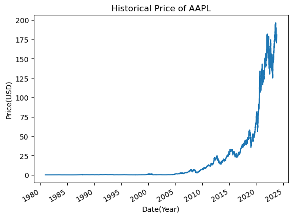

```python
#Let's take a look at some stochastic behaviors of time series
import yfinance
import pandas as pd
TIC='AAPL'
appl=yfinance.download('{}'.format(TIC))

appl['Close'].plot(title='Historical Price of {}'.format(TIC),xlabel='Date(Year)',ylabel='Price(USD)')
appl.index=pd.to_datetime(appl.index)
```

```python
from prophet import Prophet
tdf = appl.reset_index()[['Date','Close']]
```

```python
tdf['Date']=pd.to_datetime(tdf['Date'])
tdf=tdf.rename(columns={'Date':'ds','Close':'y'})
```

```python
train = tdf[(tdf['ds']<'2020-01-01')&(tdf['ds']>'2012-01-01')]
test = tdf[(tdf['ds']>'2020-01-01')]
```

```python
m = Prophet(changepoint_range=0.95)#Take 95% interval, common for identifying anomalies
m.fit(train)
```

```
12:32:20 - cmdstanpy - INFO - Chain [1] start processing
12:32:23 - cmdstanpy - INFO - Chain [1] done processing
```

```
<prophet.forecaster.Prophet at 0x13bac4cd0>
```

```python
future = m.make_future_dataframe(periods=119, freq='D')#Use trained model to make shell for prophet
```

```python
forecast = m.predict(future)
forecast[['ds','yhat','yhat_lower','yhat_upper']].tail()
```

|  | ds | yhat | yhat_lower | yhat_upper |
| --- | --- | --- | --- | --- |
| 2126 | 2020-04-24 | 84.108957 | 81.019359 | 87.451626 |
| 2127 | 2020-04-25 | 82.496447 | 79.339327 | 85.717214 |
| 2128 | 2020-04-26 | 82.627211 | 79.341986 | 85.962383 |
| 2129 | 2020-04-27 | 84.529163 | 81.320491 | 87.681244 |
| 2130 | 2020-04-28 | 84.684888 | 81.607594 | 88.047212 |

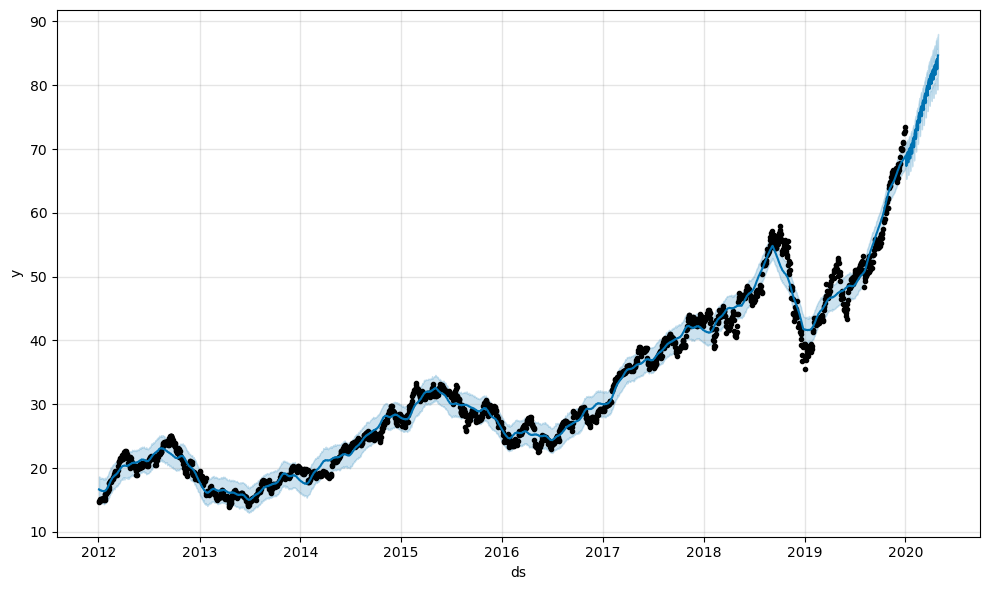

```python
result = pd.merge(tdf.set_index('ds')['y'],forecast.set_index('ds')[['yhat','yhat_lower','yhat_upper']],left_index=True,right_index=True)#pd.concat([tdf.set_index('ds')['y'], forecast.set_index('ds')[['yhat','yhat_lower','yhat_upper']]], axis=1)
fig1 = m.plot(forecast)
```

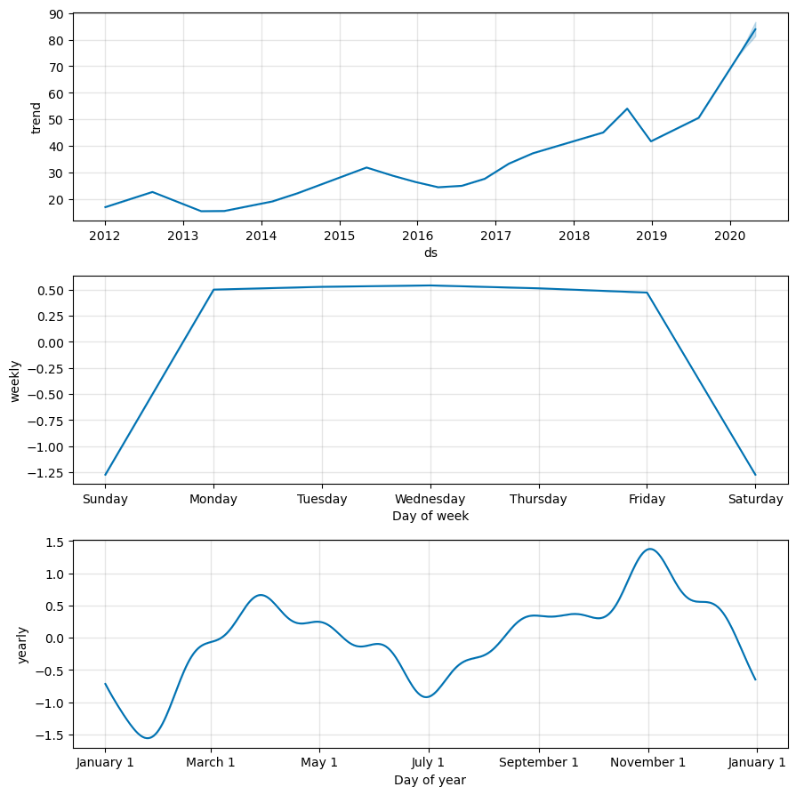

```python
comp = m.plot_components(forecast)
```

```python
result['error'] = result['y'] - result['yhat']
result['uncertainty'] = result['yhat_upper'] - result['yhat_lower']
#Confidence interval was previously set to 95%, i.e. the true value is too large to be captured by autoregressiveness
```

```python
import matplotlib.pyplot as plt
```

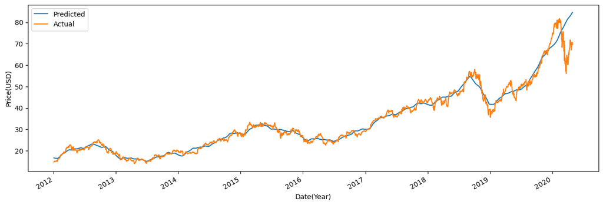

```python
result[['yhat','y']].plot(figsize=(15,5),xlabel='Date(Year)',ylabel='Price(USD)')
plt.legend(['Predicted','Actual'])
```

```python
result[result['error'].abs()>1.5*result['uncertainty']]
```

| ds | y | yhat | yhat_lower | yhat_upper | error | uncertainty |
| --- | --- | --- | --- | --- | --- | --- |
| 2018-10-03 | 58.017502 | 51.985623 | 49.978626 | 53.961516 | 6.031879 | 3.982890 |
| 2019-01-03 | 35.547501 | 41.693365 | 39.722181 | 43.499180 | -6.145865 | 3.776998 |
| 2020-01-02 | 75.087502 | 68.967388 | 67.016675 | 70.992805 | 6.120113 | 3.976130 |
| 2020-01-06 | 74.949997 | 69.258879 | 67.398474 | 71.159282 | 5.691118 | 3.760809 |
| 2020-01-08 | 75.797501 | 69.457870 | 67.430171 | 71.376089 | 6.339630 | 3.945919 |
| ... | ... | ... | ... | ... | ... | ... |
| 2020-04-22 | 69.025002 | 83.917949 | 80.944934 | 87.101230 | -14.892947 | 6.156297 |
| 2020-04-23 | 68.757500 | 84.019433 | 81.054278 | 87.175256 | -15.261933 | 6.120978 |
| 2020-04-24 | 70.742500 | 84.108957 | 81.019359 | 87.451626 | -13.366456 | 6.432267 |
| 2020-04-27 | 70.792503 | 84.529163 | 81.320491 | 87.681244 | -13.736659 | 6.360754 |
| 2020-04-28 | 69.644997 | 84.684888 | 81.607594 | 88.047212 | -15.039892 | 6.439618 |

66 rows × 6 columns

```python
result['anomaly']= result.apply(lambda x: 'Yes' if(np.abs(x['error']>1.5*x['uncertainty'])) else 'No',axis=1)
```

```python
result[result['anomaly']=='Yes'].head(3)
```

| ds | y | yhat | yhat_lower | yhat_upper | error | uncertainty | anomaly |
| --- | --- | --- | --- | --- | --- | --- | --- |
| 2018-10-03 | 58.017502 | 51.985623 | 49.978626 | 53.961516 | 6.031879 | 3.982890 | Yes |
| 2020-01-02 | 75.087502 | 68.967388 | 67.016675 | 70.992805 | 6.120113 | 3.976130 | Yes |
| 2020-01-06 | 74.949997 | 69.258879 | 67.398474 | 71.159282 | 5.691118 | 3.760809 | Yes |

```python
import plotly.express as px
fig = px.scatter(result.reset_index(),x='ds',y='y',color='anomaly',title='Visualizing anomaly for {}'.format(TIC))
fig.show()
```

[interactive chart not shown]

Disclaimer: The tutorial above is an adaptation from https://www.analyticsvidhya.com/blog/2021/12/anomaly-detection-model-using-facebook-prophet/

Note that there is also Google's ARIMA+ that you could test when working with time series.

### Research Prospects on the Hackathon (more on this during hackathon week):

Talk to each other and

- Set up initial scope of problem:
  - What is your definition of 'humanitarian crisis'
  - Agree on the scope of problem within group
  - *May need further refinement if too ambitious*
- Data, data, data
  - Scrape what information & from what platform
    - Platform-specific: Twitter: ScrapFly, Tweepy, etc., or reddit-scraping mechanisms (sub-reddit specific)
    - General solutions: the Social Watcher, Brand Watch (only looks at brand)
  - Examine what you have and start designing your final solution
    - This will determine the prospects of your final output
    - Is it a solution, is it a product, or can you think of anything else that sheds light on humanitarian crisis?
    - What best reflects the well-being of the social status of the public?
    - Identify key events

### Research Prospects on the Hackathon (more on this during hackathon week):

Talk to each other and

- Select the right target value for modeling
  - Consider what makes more sense and can be modelled
  - Might be more reasonable to leverage models like FinBERT to make intial runs on scrapped results as baselind
  - Using LLMs is by TOKEN so use your LLM access wisely, and preferrably local LLM instance
  - Is there a better numerical value to be used as target?
- Alternative Model Selection

### Hackathon Overview (WHOLE WEEK)

- DAY 1: No guest lecture, 2PM @ Library 3rd floor
- DAY 2: Guest lecture @ 9AM, 2PM @ Library 3rd floor, reflective essay due at 11:59PM;
- DAY 3: Guest lecture @ 9AM, 2PM @ Library 3rd floor, reflective essay due at 11:59PM;
- DAY 4: Guest lecture @ 9AM, 2PM @ Library 3rd floor, reflective essay due at 11:59PM;
- DAY 5: Guest lecture @ 9AM, 2PM @ Library 3rd floor, reflective essay & group presentation due at 11:59PM;

SAT & SUN: Final Presentation, Group score submission for final presentation (PDF of PPT/github link submission).

### Hackathon Overview (DAY ONE)

- General introduction of the hackathon theme and expectations (Hongshan, 15min)
- Ice-breaking ~ 1.5 hr
  - Printing/Handing out labels
  - Mingling of students (30s each, elevator pitch), particularly those wanting to be leads
  - Forming preliminary groups based on research interests (< 20 teams)
  - Self-introduction of expertise from TAs (15min)
- Group discussion on what the research topic will be + research time (1hr)
- Group initial proposal on their topic (3min each) approx. 1hr
- Wrap-up: Questions we observed? From students and TAs (15mins)
- Release Group-Name Signups Google Form for group-specific channels to be created on slack.